# Tipología y ciclo de vida de los datos: Práctica 2: Limpieza y validación de los datos

Autores: Youness El Guennouni y Mario Gutiérrez Calvo de Mora

Mayo 2019

# Introducción

A título de muestra, trabajaremos con el juego de datos “Titanic” que recoge datos sobre el famoso crucero y sobre el que es fácil realizar tareas de clasificación predictiva sobre la variable “Survived”.

De momento dejaremos para las siguientes prácticas el estudio de algoritmos predictivos y nos centraremos por ahora en el estudio de las variables de un juego de datos, es decir, haremos un trabajo descriptivo del mismo.

Las actividades que llevaremos a cabo en esta práctica suelen enmarcarse en las fases iniciales de un proyecto de minería de datos y consisten en la selección de caraterísticas o variables y la preparación del juego de datos para posteriormente ser consumido por un algoritmo.

Las técnicas que trabajaremos son las siguientes:

1. Normalización
2. Discretización
3. Gestión de valores nulos
4. Estudio de correlaciones
5. Reducción de la dimensionalidad
6. Análisis visual del juego de datos

# Ejemplo de estudio visual con el juego de datos Titanic

## Procesos de limpieza del juego de datos

Primer contacto con el juego de datos, visualizamos su estructura.

```r
# Guardamos el juego de datos test y train en un único dataset
test <- read.csv('./data/titanic-test.csv',stringsAsFactors = FALSE)
train <- read.csv('./data/titanic-train.csv', stringsAsFactors = FALSE)

# Unimos los dos juetos de datos en uno solo
totalData <- bind_rows(train,test)
filas=dim(train)[1]

# Verificamos la estructura del juego de datos
str(totalData)
```

```
## 'data.frame':    1309 obs. of  13 variables:
##  $ PassengerId                                                            : int  1 2 3 4 5 6 7 8 9 10 ...
##  $ Survived                                                               : int  0 1 1 1 0 0 0 0 1 1 ...
##  $ Pclass                                                                 : int  3 1 3 1 3 3 1 3 3 2 ...
##  $ Name                                                                   : chr  "Braund, Mr. Owen Harris" "Cumings, Mrs. John Bradley (Florence Briggs Thayer)" "Heikkinen, Miss. Laina" "Futrelle, Mrs. Jacques Heath (Lily May Peel)" ...
##  $ Sex                                                                    : chr  "male" "female" "female" "female" ...
##  $ Age                                                                    : num  22 38 26 35 35 NA 54 2 27 14 ...
##  $ SibSp                                                                  : int  1 1 0 1 0 0 0 3 0 1 ...
##  $ Parch                                                                  : int  0 0 0 0 0 0 0 1 2 0 ...
##  $ Ticket                                                                 : chr  "A/5 21171" "PC 17599" "STON/O2. 3101282" "113803" ...
##  $ Fare                                                                   : num  7.25 71.28 7.92 53.1 8.05 ...
##  $ Cabin                                                                  : chr  "" "C85" "" "C123" ...
##  $ Embarked                                                               : chr  "S" "C" "S" "S" ...
##  $ PassengerId.Pclass.Name.Sex.Age.SibSp.Parch.Ticket.Fare.Cabin.Embarked.: chr  NA NA NA NA ...
```

Trabajamos los atributos con valores vacíos.

```r
# Estadísticas de valores vacíos
colSums(is.na(totalData))
```

```
##                                                             PassengerId
##                                                                     418
##                                                                Survived
##                                                                     418
##                                                                  Pclass
##                                                                     418
##                                                                    Name
##                                                                     418
##                                                                     Sex
##                                                                     418
##                                                                     Age
##                                                                     595
##                                                                   SibSp
##                                                                     418
##                                                                   Parch
##                                                                     418
##                                                                  Ticket
##                                                                     418
##                                                                    Fare
##                                                                     418
##                                                                   Cabin
##                                                                     418
##                                                                Embarked
##                                                                     418
## PassengerId.Pclass.Name.Sex.Age.SibSp.Parch.Ticket.Fare.Cabin.Embarked.
##                                                                     891
```

```r
colSums(totalData=="")
```

```
##                                                             PassengerId
##                                                                      NA
##                                                                Survived
##                                                                      NA
##                                                                  Pclass
##                                                                      NA
##                                                                    Name
##                                                                      NA
##                                                                     Sex
##                                                                      NA
##                                                                     Age
##                                                                      NA
##                                                                   SibSp
##                                                                      NA
##                                                                   Parch
##                                                                      NA
##                                                                  Ticket
##                                                                      NA
##                                                                    Fare
##                                                                      NA
##                                                                   Cabin
##                                                                      NA
##                                                                Embarked
##                                                                      NA
## PassengerId.Pclass.Name.Sex.Age.SibSp.Parch.Ticket.Fare.Cabin.Embarked.
##                                                                      NA
```

```r
# Tomamos valor "C" para los valores vacíos de la variable "Embarked"
totalData$Embarked[totalData$Embarked==""]="C"

#Para los valores perdidos procedemos con aplicar la distancia de Gower
totalData <- kNN(totalData)
```

Discretizamos cuando tiene sentido y en función de cada variable.

```r
# Â¿Para qué variables tendría sentido un proceso de discretización?
apply(totalData,2, function(x) length(unique(x)))
```

```
##                                                                 PassengerId
##                                                                         891
##                                                                    Survived
##                                                                           2
##                                                                      Pclass
##                                                                           3
##                                                                        Name
##                                                                         891
##                                                                         Sex
##                                                                           2
##                                                                         Age
##                                                                          88
##                                                                       SibSp
##                                                                           7
##                                                                       Parch
##                                                                           7
##                                                                      Ticket
##                                                                         681
##                                                                        Fare
##                                                                         248
##                                                                       Cabin
##                                                                         148
##                                                                    Embarked
##                                                                           3
##     PassengerId.Pclass.Name.Sex.Age.SibSp.Parch.Ticket.Fare.Cabin.Embarked.
##                                                                         397
##                                                             PassengerId_imp
##                                                                           2
##                                                                Survived_imp
##                                                                           2
##                                                                  Pclass_imp
##                                                                           2
##                                                                    Name_imp
##                                                                           2
##                                                                     Sex_imp
##                                                                           2
##                                                                     Age_imp
##                                                                           2
##                                                                   SibSp_imp
##                                                                           2
##                                                                   Parch_imp
##                                                                           2
##                                                                  Ticket_imp
##                                                                           2
##                                                                    Fare_imp
##                                                                           2
##                                                                   Cabin_imp
##                                                                           2
##                                                                Embarked_imp
##                                                                           2
## PassengerId.Pclass.Name.Sex.Age.SibSp.Parch.Ticket.Fare.Cabin.Embarked._imp
##                                                                           2
```

```r
# Discretizamos las variables con pocas clases
cols<-c("Survived","Pclass","Sex","Embarked")
for (i in cols){
  totalData[,i] <- as.factor(totalData[,i])
}

# Después de los cambios, analizamos la nueva estructura del juego de datos
str(totalData)
```

```
## 'data.frame':    1309 obs. of  26 variables:
##  $ PassengerId                                                                : int  1 2 3 4 5 6 7 8 9 10 ...
##  $ Survived                                                                   : Factor w/ 2 levels "0","1": 1 2 2 2 1 1 1 1 2 2 ...
##  $ Pclass                                                                     : Factor w/ 3 levels "1","2","3": 3 1 3 1 3 3 1 3 3 2 ...
##  $ Name                                                                       : chr  "Braund, Mr. Owen Harris" "Cumings, Mrs. John Bradley (Florence Briggs Thayer)" "Heikkinen, Miss. Laina" "Futrelle, Mrs. Jacques Heath (Lily May Peel)" ...
##  $ Sex                                                                        : Factor w/ 2 levels "female","male": 2 1 1 1 2 2 2 2 1 1 ...
##  $ Age                                                                        : num  22 38 26 35 35 21 54 2 27 14 ...
##  $ SibSp                                                                      : int  1 1 0 1 0 0 0 3 0 1 ...
##  $ Parch                                                                      : int  0 0 0 0 0 0 0 1 2 0 ...
##  $ Ticket                                                                     : chr  "A/5 21171" "PC 17599" "STON/O2. 3101282" "113803" ...
##  $ Fare                                                                       : num  7.25 71.28 7.92 53.1 8.05 ...
##  $ Cabin                                                                      : chr  "" "C85" "" "C123" ...
##  $ Embarked                                                                   : Factor w/ 3 levels "C","Q","S": 3 1 3 3 3 2 3 3 3 1 ...
##  $ PassengerId.Pclass.Name.Sex.Age.SibSp.Parch.Ticket.Fare.Cabin.Embarked.    : chr  " Mrs. James (Ellen Needs);female;47;1;0;363272;7;;S" " Mr. James;male;34.5;0;0;330911;78.292;;Q" " Mrs. James (Ellen Needs);female;47;1;0;363272;7;;S" " Mrs. Alexander (Helga E Lindqvist);female;22;1;1;3101298;1…
##  $ PassengerId_imp                                                            : logi  FALSE FALSE FALSE FALSE FALSE FALSE ...
##  $ Survived_imp                                                               : logi  FALSE FALSE FALSE FALSE FALSE FALSE ...
##  $ Pclass_imp                                                                 : logi  FALSE FALSE FALSE FALSE FALSE FALSE ...
##  $ Name_imp                                                                   : logi  FALSE FALSE FALSE FALSE FALSE FALSE ...
##  $ Sex_imp                                                                    : logi  FALSE FALSE FALSE FALSE FALSE FALSE ...
##  $ Age_imp                                                                    : logi  FALSE FALSE FALSE FALSE FALSE TRUE ...
##  $ SibSp_imp                                                                  : logi  FALSE FALSE FALSE FALSE FALSE FALSE ...
##  $ Parch_imp                                                                  : logi  FALSE FALSE FALSE FALSE FALSE FALSE ...
##  $ Ticket_imp                                                                 : logi  FALSE FALSE FALSE FALSE FALSE FALSE ...
##  $ Fare_imp                                                                   : logi  FALSE FALSE FALSE FALSE FALSE FALSE ...
##  $ Cabin_imp                                                                  : logi  FALSE FALSE FALSE FALSE FALSE FALSE ...
##  $ Embarked_imp                                                               : logi  FALSE FALSE FALSE FALSE FALSE FALSE ...
##  $ PassengerId.Pclass.Name.Sex.Age.SibSp.Parch.Ticket.Fare.Cabin.Embarked._imp: logi  TRUE TRUE TRUE TRUE TRUE TRUE ...
```

Cuadro de las estimaciónes no robustas y robustas.

```r
age_s<-summary(totalData$Age)
pclass_s<-summary(totalData$Pclass)
sibSp_s<-summary(totalData$SibSp)
parch_s<-summary(totalData$Parch)
fare_s<-summary(totalData$Fare)

table_s <- suppressWarnings(rbind(age_s,pclass_s,sibSp_s,parch_s, fare_s))
age_r <- c(sd(totalData$Age), winsor.mean(totalData$Age,trim=0.05), IQR(totalData$Age))
pclass_r <- c(sd(totalData$Pclass), "NA", IQR(totalData$Pclass))
#pclass_r <- c(sd(totalData$Pclass), winsor.mean(totalData$Pclass,trim=0.05), IQR(totalData$Pclass))
sibSp_r <- c(sd(totalData$SibSp), winsor.mean(totalData$SibSp,trim=0.05), IQR(totalData$SibSp))
parch_r <- c(sd(totalData$Parch), winsor.mean(totalData$Parch,trim=0.05), IQR(totalData$Parch))
fare_r <- c(sd(totalData$Fare), winsor.mean(totalData$Fare,trim=0.05), IQR(totalData$Fare))

table_r <- rbind(age_r,pclass_r,sibSp_r, parch_r, fare_r)
table_res <- cbind(table_s, table_r)
colnames( table_res) <- c("Min", "1st Qu", "Median", "Mean", "3rd Qu", "Max", "SD", "WINSOR", "IQR")
kable(table_res)
```

[output not shown]

```r
#Los valores atípicos SibSp.
boxplot.stats(totalData$SibSp)$out
```

```
## integer(0)
```

```r
#Los valores atípicos Parch.
boxplot.stats(totalData$Parch)$out
```

```
## [1] 6
```

```r
#Los valores atípicos Fare.
boxplot.stats(totalData$Fare)$out
```

```
##  [1] 263.0000 146.5208 263.0000 247.5208 146.5208 113.2750 512.3292
##  [8] 153.4625 135.6333 151.5500 247.5208 151.5500 110.8833 108.9000
## [15] 262.3750 164.8667 134.5000 135.6333 153.4625 133.6500 134.5000
## [22] 263.0000 135.6333 211.5000 227.5250 120.0000 113.2750 120.0000
## [29] 263.0000 151.5500 108.9000 221.7792 106.4250 106.4250 110.8833
## [36] 227.5250 110.8833 153.4625 113.2750 133.6500 512.3292 211.3375
## [43] 110.8833 227.5250 151.5500 227.5250 211.3375 512.3292 262.3750
## [50] 120.0000 211.3375 120.0000 164.8667
```

Remplazamos a los valores atípicos

```r
#Parch
qnt <- quantile(totalData$Parch, probs=c(.25, .75), na.rm = T)
caps <- quantile(totalData$Parch, probs=c(.05, .95), na.rm = T)
H <- 1.5 * IQR(totalData$Parch, na.rm = T)
totalData$Parch[totalData$Parch < (qnt[1] - H)] <- caps[1]
totalData$Parch[totalData$Parch > (qnt[1] + H)] <- caps[2]

#Fare
qnt <- quantile(totalData$Fare, probs=c(.25, .75), na.rm = T)
caps <- quantile(totalData$Fare, probs=c(.05, .95), na.rm = T)
H <- 1.5 * IQR(totalData$Fare, na.rm = T)
totalData$Fare[totalData$Fare < (qnt[1] - H)] <- caps[1]
totalData$Fare[totalData$Fare > (qnt[1] + H)] <- caps[2]

#Los valores atípicos Parch.
boxplot.stats(totalData$Parch)$out
```

```
## numeric(0)
```

```r
#Los valores atípicos Fare.
boxplot.stats(totalData$Fare)$out
```

```
## numeric(0)
```

## Procesos de análisis del juego de datos

Nos proponemos analizar las relaciones entre las diferentes variables del juego de datos.

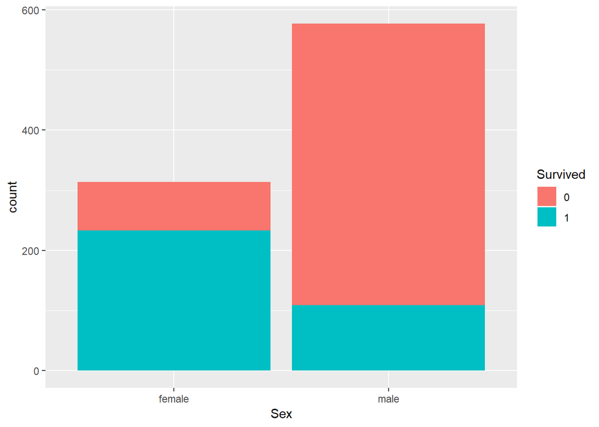

```r
# Visualizamos la relación entre las variables "sex" y "survival":
ggplot(data=totalData[1:filas,],aes(x=Sex,fill=Survived))+geom_bar()
```

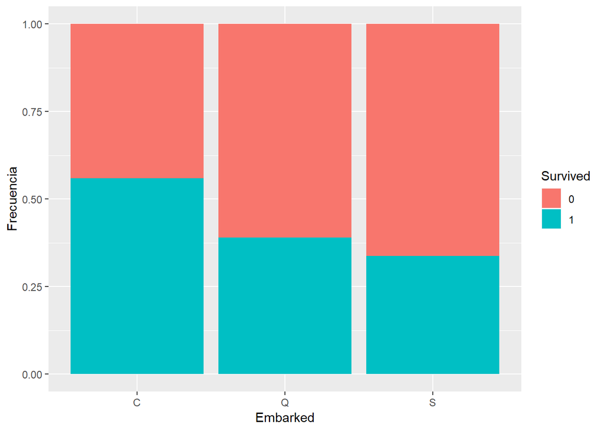

```r
# Otro punto de vista. Survival como función de Embarked:
ggplot(data = totalData[1:filas,],aes(x=Embarked,fill=Survived))+geom_bar(position="fill")+ylab("Frecuencia")
```

Obtenemos una matriz de porcentages de frecuencia.  
Vemos, por ejemplo que la probabilidad de sobrebivir si se embarcó en “C” es de un 55,88%

```r
t<-table(totalData[1:filas,]$Embarked,totalData[1:filas,]$Survived)
for (i in 1:dim(t)[1]){
    t[i,]<-t[i,]/sum(t[i,])*100
}
t
```

```
##
##            0        1
##   C 44.11765 55.88235
##   Q 61.03896 38.96104
##   S 66.30435 33.69565
```

Veamos ahora como en un mismo gráfico de frecuencias podemos trabajar con 3 variables: Embarked, Survived y Pclass.

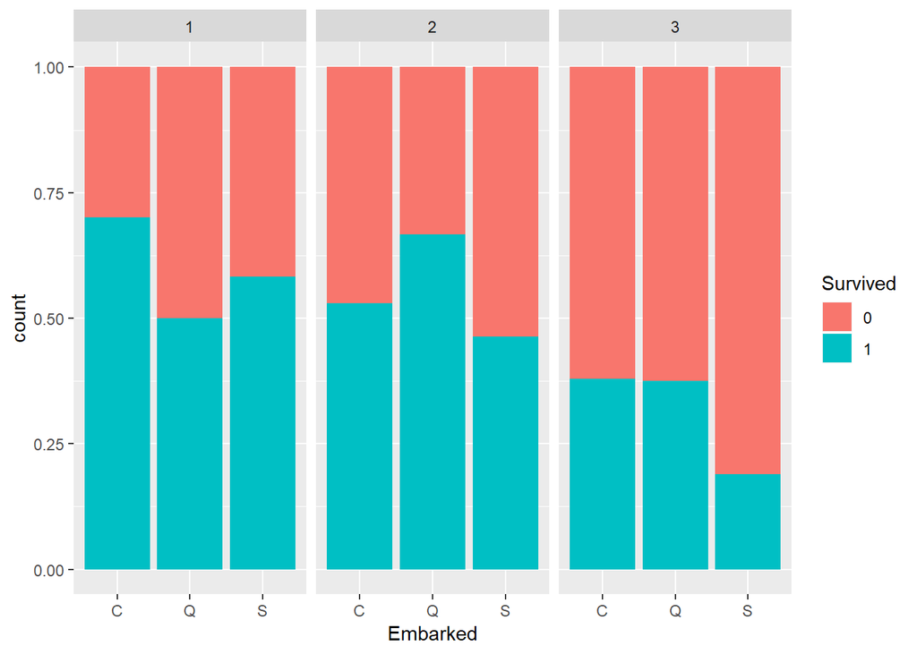

```r
# Now, let's devide the graph of Embarked by Pclass:
ggplot(data = totalData[1:filas,],aes(x=Embarked,fill=Survived))+geom_bar(position="fill")+facet_wrap(~Pclass)
```

Comparemos ahora dos gráficos de frecuencias: Survived-SibSp y Survived-Parch

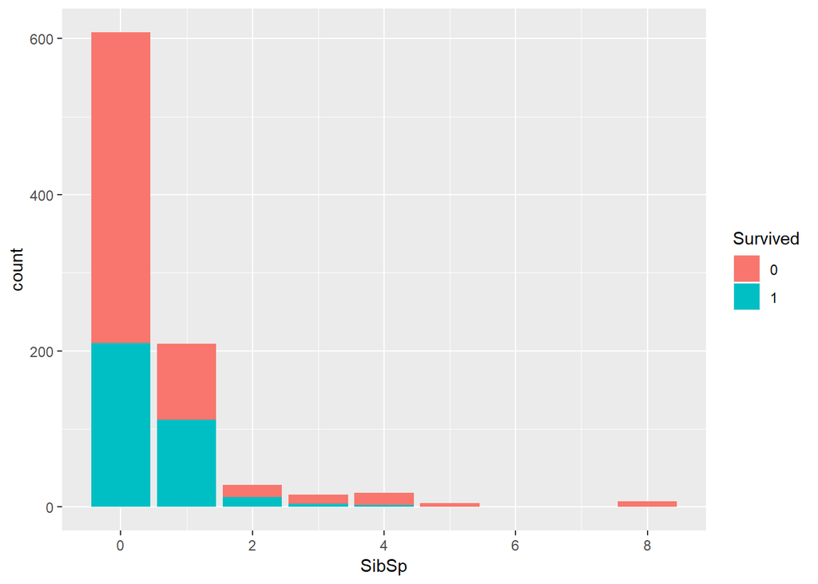

```r
# Survivial como función de SibSp y Parch
ggplot(data = totalData[1:filas,],aes(x=SibSp,fill=Survived))+geom_bar()
```